# Wrangling of the BackOrder dataset

**Goal :** Prepare the backorder dataset for EDA and Modeling

```python
# Importing the packages
import pandas as pd
import numpy as np
import matplotlib.pylab as plt
import seaborn as sns
from sklearn.model_selection import train_test_split
from sklearn.linear_model import LinearRegression
%matplotlib inline
```

```python
df = pd.read_csv('../Backorder_train.csv')
```

```python
df.head()
```

|  | sku | national_inv | lead_time | in_transit_qty | forecast_3_month | forecast_6_month | forecast_9_month | sales_1_month | sales_3_month | sales_6_month | ... | pieces_past_due | perf_6_month_avg | perf_12_month_avg | local_bo_qty | deck_risk | oe_constraint | ppap_risk | stop_auto_buy | rev_stop | went_on_backorder |
| --- | --- | --- | --- | --- | --- | --- | --- | --- | --- | --- | --- | --- | --- | --- | --- | --- | --- | --- | --- | --- | --- |
| 0 | 1026827 | 0.0 | NaN | 0.0 | 0.0 | 0.0 | 0.0 | 0.0 | 0.0 | 0.0 | ... | 0.0 | -99.00 | -99.00 | 0.0 | No | No | No | Yes | No | No |
| 1 | 1043384 | 2.0 | 9.0 | 0.0 | 0.0 | 0.0 | 0.0 | 0.0 | 0.0 | 0.0 | ... | 0.0 | 0.99 | 0.99 | 0.0 | No | No | No | Yes | No | No |
| 2 | 1043696 | 2.0 | NaN | 0.0 | 0.0 | 0.0 | 0.0 | 0.0 | 0.0 | 0.0 | ... | 0.0 | -99.00 | -99.00 | 0.0 | Yes | No | No | Yes | No | No |
| 3 | 1043852 | 7.0 | 8.0 | 0.0 | 0.0 | 0.0 | 0.0 | 0.0 | 0.0 | 0.0 | ... | 0.0 | 0.10 | 0.13 | 0.0 | No | No | No | Yes | No | No |
| 4 | 1044048 | 8.0 | NaN | 0.0 | 0.0 | 0.0 | 0.0 | 0.0 | 0.0 | 0.0 | ... | 0.0 | -99.00 | -99.00 | 0.0 | Yes | No | No | Yes | No | No |

5 rows × 23 columns

```python
df.shape
```

```
(1687861, 23)
```

```python
df.info()
```

```
<class 'pandas.core.frame.DataFrame'>
RangeIndex: 1687861 entries, 0 to 1687860
Data columns (total 23 columns):
sku                  1687861 non-null object
national_inv         1687860 non-null float64
lead_time            1586967 non-null float64
in_transit_qty       1687860 non-null float64
forecast_3_month     1687860 non-null float64
forecast_6_month     1687860 non-null float64
forecast_9_month     1687860 non-null float64
sales_1_month        1687860 non-null float64
sales_3_month        1687860 non-null float64
sales_6_month        1687860 non-null float64
sales_9_month        1687860 non-null float64
min_bank             1687860 non-null float64
potential_issue      1687860 non-null object
pieces_past_due      1687860 non-null float64
perf_6_month_avg     1687860 non-null float64
perf_12_month_avg    1687860 non-null float64
local_bo_qty         1687860 non-null float64
deck_risk            1687860 non-null object
oe_constraint        1687860 non-null object
ppap_risk            1687860 non-null object
stop_auto_buy        1687860 non-null object
rev_stop             1687860 non-null object
went_on_backorder    1687860 non-null object
dtypes: float64(15), object(8)
memory usage: 296.2+ MB
```

It looks like there are some columns with mixed data types (as also evident from the pandas warning while loading csv). We will need to identify and clean them up. Some of the column names also need to be changed for better readability.

```python
# Renaming columns
new_column_names =['product_id','current_inventory','transit_duration','transit_quantity',
                   'forecast_sales_3_months', 'forecast_sales_6_months', 'forecast_sales_9_months',
                   'prior_sales_1_month', 'prior_sales_3_month', 'prior_sales_6_month', 'prior_sales_9_month',
                   'minimum_recommended_stock','source_has_issue', 'source_overdue', 'source_performance_6_months',
                   'source_performance_12_months', 'stock_overdue', 'deck_risk', 'oe_constraint','ppap_risk',
                   'stop_auto_buy', 'rev_stop','went_on_backorder']

df.columns = new_column_names
```

```python
df.head()
```

|  | product_id | current_inventory | transit_duration | transit_quantity | forecast_sales_3_months | forecast_sales_6_months | forecast_sales_9_months | prior_sales_1_month | prior_sales_3_month | prior_sales_6_month | ... | source_overdue | source_performance_6_months | source_performance_12_months | stock_overdue | deck_risk | oe_constraint | ppap_risk | stop_auto_buy | rev_stop | went_on_backorder |
| --- | --- | --- | --- | --- | --- | --- | --- | --- | --- | --- | --- | --- | --- | --- | --- | --- | --- | --- | --- | --- | --- |
| 0 | 1026827 | 0.0 | NaN | 0.0 | 0.0 | 0.0 | 0.0 | 0.0 | 0.0 | 0.0 | ... | 0.0 | -99.00 | -99.00 | 0.0 | No | No | No | Yes | No | No |
| 1 | 1043384 | 2.0 | 9.0 | 0.0 | 0.0 | 0.0 | 0.0 | 0.0 | 0.0 | 0.0 | ... | 0.0 | 0.99 | 0.99 | 0.0 | No | No | No | Yes | No | No |
| 2 | 1043696 | 2.0 | NaN | 0.0 | 0.0 | 0.0 | 0.0 | 0.0 | 0.0 | 0.0 | ... | 0.0 | -99.00 | -99.00 | 0.0 | Yes | No | No | Yes | No | No |
| 3 | 1043852 | 7.0 | 8.0 | 0.0 | 0.0 | 0.0 | 0.0 | 0.0 | 0.0 | 0.0 | ... | 0.0 | 0.10 | 0.13 | 0.0 | No | No | No | Yes | No | No |
| 4 | 1044048 | 8.0 | NaN | 0.0 | 0.0 | 0.0 | 0.0 | 0.0 | 0.0 | 0.0 | ... | 0.0 | -99.00 | -99.00 | 0.0 | Yes | No | No | Yes | No | No |

5 rows × 23 columns

```python
df.describe()
```

|  | current_inventory | transit_duration | transit_quantity | forecast_sales_3_months | forecast_sales_6_months | forecast_sales_9_months | prior_sales_1_month | prior_sales_3_month | prior_sales_6_month | prior_sales_9_month | minimum_recommended_stock | source_overdue | source_performance_6_months | source_performance_12_months | stock_overdue |
| --- | --- | --- | --- | --- | --- | --- | --- | --- | --- | --- | --- | --- | --- | --- | --- |
| count | 1.687860e+06 | 1.586967e+06 | 1.687860e+06 | 1.687860e+06 | 1.687860e+06 | 1.687860e+06 | 1.687860e+06 | 1.687860e+06 | 1.687860e+06 | 1.687860e+06 | 1.687860e+06 | 1.687860e+06 | 1.687860e+06 | 1.687860e+06 | 1.687860e+06 |
| mean | 4.961118e+02 | 7.872267e+00 | 4.405202e+01 | 1.781193e+02 | 3.449867e+02 | 5.063644e+02 | 5.592607e+01 | 1.750259e+02 | 3.417288e+02 | 5.252697e+02 | 5.277230e+01 | 2.043724e+00 | -6.872059e+00 | -6.437947e+00 | 6.264507e-01 |
| std | 2.961523e+04 | 7.056024e+00 | 1.342742e+03 | 5.026553e+03 | 9.795152e+03 | 1.437892e+04 | 1.928196e+03 | 5.192378e+03 | 9.613167e+03 | 1.483861e+04 | 1.254983e+03 | 2.360165e+02 | 2.655636e+01 | 2.584333e+01 | 3.372224e+01 |
| min | -2.725600e+04 | 0.000000e+00 | 0.000000e+00 | 0.000000e+00 | 0.000000e+00 | 0.000000e+00 | 0.000000e+00 | 0.000000e+00 | 0.000000e+00 | 0.000000e+00 | 0.000000e+00 | 0.000000e+00 | -9.900000e+01 | -9.900000e+01 | 0.000000e+00 |
| 25% | 4.000000e+00 | 4.000000e+00 | 0.000000e+00 | 0.000000e+00 | 0.000000e+00 | 0.000000e+00 | 0.000000e+00 | 0.000000e+00 | 0.000000e+00 | 0.000000e+00 | 0.000000e+00 | 0.000000e+00 | 6.300000e-01 | 6.600000e-01 | 0.000000e+00 |
| 50% | 1.500000e+01 | 8.000000e+00 | 0.000000e+00 | 0.000000e+00 | 0.000000e+00 | 0.000000e+00 | 0.000000e+00 | 1.000000e+00 | 2.000000e+00 | 4.000000e+00 | 0.000000e+00 | 0.000000e+00 | 8.200000e-01 | 8.100000e-01 | 0.000000e+00 |
| 75% | 8.000000e+01 | 9.000000e+00 | 0.000000e+00 | 4.000000e+00 | 1.200000e+01 | 2.000000e+01 | 4.000000e+00 | 1.500000e+01 | 3.100000e+01 | 4.700000e+01 | 3.000000e+00 | 0.000000e+00 | 9.700000e-01 | 9.500000e-01 | 0.000000e+00 |
| max | 1.233440e+07 | 5.200000e+01 | 4.894080e+05 | 1.427612e+06 | 2.461360e+06 | 3.777304e+06 | 7.417740e+05 | 1.105478e+06 | 2.146625e+06 | 3.205172e+06 | 3.133190e+05 | 1.464960e+05 | 1.000000e+00 | 1.000000e+00 | 1.253000e+04 |

```python
df.describe(include=['object'])
```

|  | product_id | source_has_issue | deck_risk | oe_constraint | ppap_risk | stop_auto_buy | rev_stop | went_on_backorder |
| --- | --- | --- | --- | --- | --- | --- | --- | --- |
| count | 1687861 | 1687860 | 1687860 | 1687860 | 1687860 | 1687860 | 1687860 | 1687860 |
| unique | 1687861 | 2 | 2 | 2 | 2 | 2 | 2 | 2 |
| top | 3279755 | No | No | No | No | Yes | No | No |
| freq | 1 | 1686953 | 1300377 | 1687615 | 1484026 | 1626774 | 1687129 | 1676567 |

```python
#checking the nulls
df.isnull().sum()
```

```
product_id                           0
current_inventory                    1
transit_duration                100894
transit_quantity                     1
forecast_sales_3_months              1
forecast_sales_6_months              1
forecast_sales_9_months              1
prior_sales_1_month                  1
prior_sales_3_month                  1
prior_sales_6_month                  1
prior_sales_9_month                  1
minimum_recommended_stock            1
source_has_issue                     1
source_overdue                       1
source_performance_6_months          1
source_performance_12_months         1
stock_overdue                        1
deck_risk                            1
oe_constraint                        1
ppap_risk                            1
stop_auto_buy                        1
rev_stop                             1
went_on_backorder                    1
dtype: int64
```

Many of the columns have just a single null entry. Quite possible that all these NaN belong to same row which might be header or footer. If we will remove this row it will also solve the mix datatype issue which we saw during data load.

There are nulls and lots of 0's in each column. During the EDA/Feature engineering step we can determine if we want to omit or keep this column. But for now we will look for an approach to fill theses missing values.

```python
df[df.current_inventory.isnull()]
```

|  | product_id | current_inventory | transit_duration | transit_quantity | forecast_sales_3_months | forecast_sales_6_months | forecast_sales_9_months | prior_sales_1_month | prior_sales_3_month | prior_sales_6_month | ... | source_overdue | source_performance_6_months | source_performance_12_months | stock_overdue | deck_risk | oe_constraint | ppap_risk | stop_auto_buy | rev_stop | went_on_backorder |
| --- | --- | --- | --- | --- | --- | --- | --- | --- | --- | --- | --- | --- | --- | --- | --- | --- | --- | --- | --- | --- | --- |
| 1687860 | (1687860 rows) | NaN | NaN | NaN | NaN | NaN | NaN | NaN | NaN | NaN | ... | NaN | NaN | NaN | NaN | NaN | NaN | NaN | NaN | NaN | NaN |

1 rows × 23 columns

```python
df.drop(1687860, inplace=True)
```

```python
df.isnull().sum()
```

```
product_id                           0
current_inventory                    0
transit_duration                100893
transit_quantity                     0
forecast_sales_3_months              0
forecast_sales_6_months              0
forecast_sales_9_months              0
prior_sales_1_month                  0
prior_sales_3_month                  0
prior_sales_6_month                  0
prior_sales_9_month                  0
minimum_recommended_stock            0
source_has_issue                     0
source_overdue                       0
source_performance_6_months          0
source_performance_12_months         0
stock_overdue                        0
deck_risk                            0
oe_constraint                        0
ppap_risk                            0
stop_auto_buy                        0
rev_stop                             0
went_on_backorder                    0
dtype: int64
```

```python
df.product_id = df.product_id.astype(int)
```

Missing values in columns **source_performance_6_months** and **source_performance_12_months** are represented as **-99**. source_performance_6_months has **129478** & source_performance_12_months has **122050** missing values.

Heatmap shows tha there is strong correlation between **source_performance_6_months** and **source_performance_12_months**. So, linear regression can be used to filing missing values. However another interesting point to note here is that many observations have both source_performance_12_months and source_performance_6_months as null, so linear regression cannot fill such values and we need to see another approach there. Probably we would like now to check for the central tendency of the data and replace the null accordingly. It’s clearly visible from violin plot that data is not distributed normally. So we can pick median to fill remaining values

For **Transit Duration** I don't see correlation of this attribute with other features and also data is not distributed normally. So, again we can choose median to fill the nulls.

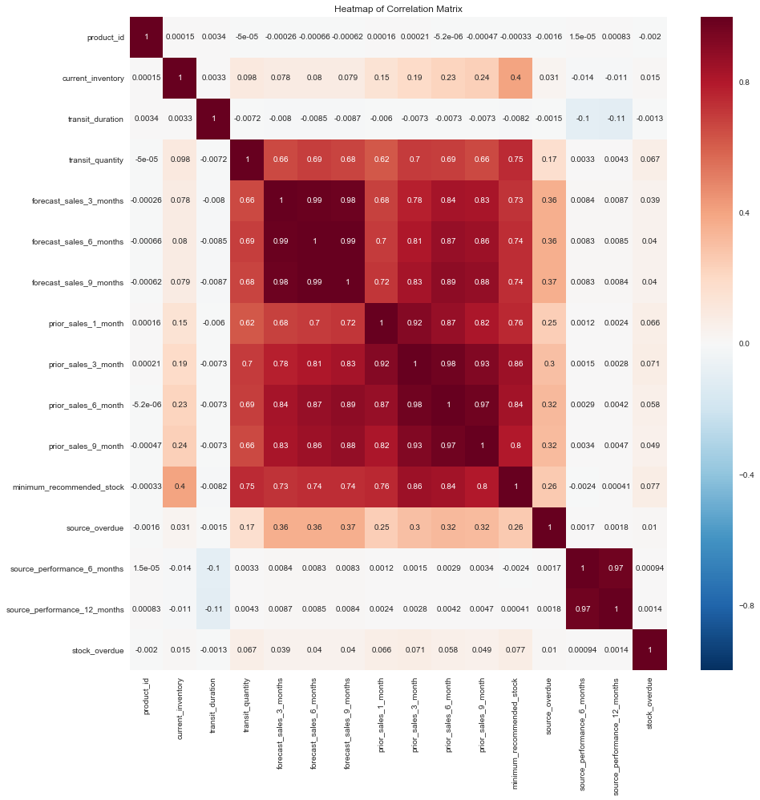

```python
# Find the correlation
fig, ax = plt.subplots(figsize=(15,15))
col_corr =df.corr()
sns.heatmap(col_corr, annot=True)
sns.plt.title('Heatmap of Correlation Matrix')
```

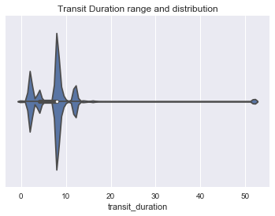

```python
# View range and distribution
sns.violinplot(df.transit_duration)
sns.plt.title('Transit Duration range and distribution')
```

```python
#Fill null with median value
df['transit_duration']=df.transit_duration.fillna(df.transit_duration.median())
df.transit_duration.isnull().sum()
```

```
0
```

```python
#Checking for the duplicates
df.product_id.duplicated().sum()
```

```
0
```

```python
# Replace -99 with Nan
df.source_performance_6_months.replace({-99.00:np.nan}, inplace=True)
df.source_performance_12_months.replace({-99.00:np.nan}, inplace=True)
```

```python
(df.source_performance_6_months == -99.00).sum()
```

```
0
```

```python
(df.source_performance_12_months == -99).sum()
```

```
0
```

```python
#LinearRegression for filling the Nan
X_12months = df[df.source_performance_6_months.notnull() & df.source_performance_12_months.notnull()][['source_performance_12_months']]
y_6months = df[df.source_performance_6_months.notnull() & df.source_performance_12_months.notnull()]['source_performance_6_months']
```

```python
linReg = LinearRegression()
linReg.fit(X_12months,y_6months)
```

```
LinearRegression(copy_X=True, fit_intercept=True, n_jobs=1, normalize=False)
```

```python
#Predicted Nan values
test_12months = df[df.source_performance_6_months.isnull() & df.source_performance_12_months.notnull()][['source_performance_12_months']]
pred_6months = linReg.predict(test_12months)
```

```python
# Fill the null values
reg_6_months_list = list(zip(test_12months.index,pred_6months))
for val in reg_6_months_list:
      df.set_value(index=val[0], value =val[1], col='source_performance_6_months')
```

```python
#Check if the value is inserted
df.source_performance_6_months.isnull().sum()
```

```
122050
```

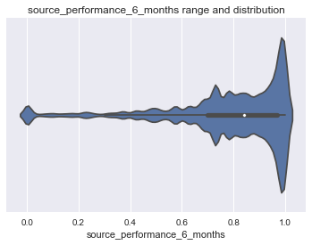

```python
# View range and distribution
sns.violinplot(df.source_performance_6_months)
sns.plt.title('source_performance_6_months range and distribution')
```

```python
#impute null with median
df.source_performance_6_months.fillna(df.source_performance_6_months.median(), inplace=True)
```

```python
df.source_performance_6_months.isnull().sum()
```

```
0
```

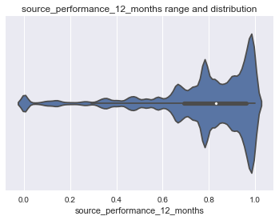

```python
# View range and distribution
sns.violinplot(df.source_performance_12_months)
sns.plt.title('source_performance_12_months range and distribution')
```

```python
#impute null with median
df.source_performance_12_months.fillna(df.source_performance_12_months.median(), inplace=True)
df.source_performance_12_months.isnull().sum()
```

```
0
```

```python
# write the clean data to a CSV file
df.to_csv('../Backorder_clean.csv')
```